# Transportation

## Travel Dates, Length of Stay, and Ports of Travel

## Travel Dates

### Arrival Date to Black Rock City

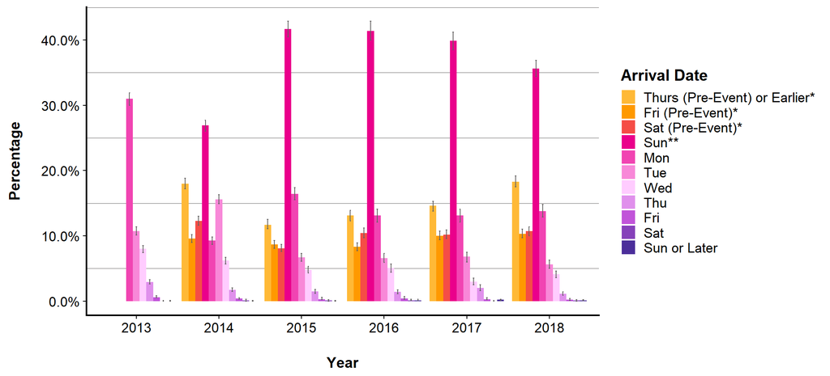

Error bars indicate the upper and lower bounds of the 95% confidence intervals.

* Pre-event arrival data from the 2013 online survey have been removed because the survey question in 2013 was less precise than it was in later years, so the 2013 pre-event data is not directly comparable.  
** In 2013 and 2014 Burning Man's official opening date fell on a Monday, so for these years Sunday arrivals should be considered pre-event. From 2015-18 Burning Man opened on a Sunday, so for these years Sunday arrivals should not be considered pre-event arrivals.

|  | 2013 Percent | 2013 MoE +/- % |  | 2014 Percent | 2014 MoE +/- % |  | 2015 Percent | 2015 MoE +/- % |  | 2016 Percent | 2016 MoE +/- % |  | 2017 Percent | 2017 MoE +/- % |  | 2018 Percent | 2018 MoE +/- % |
| --- | --- | --- | --- | --- | --- | --- | --- | --- | --- | --- | --- | --- | --- | --- | --- | --- | --- |
| Thurs (Pre-Event) or Earlier* | NA | NA |  | 18.0 | 0.8 |  | 11.7 | 0.8 |  | 13.1 | 0.8 |  | 14.6 | 0.8 |  | 18.3 | 0.8 |
| Fri (Pre-Event)* | NA | NA |  | 9.6 | 0.6 |  | 8.7 | 0.6 |  | 8.3 | 0.6 |  | 10.0 | 0.6 |  | 10.3 | 0.6 |
| Sat (Pre-Event)* | NA | NA |  | 12.3 | 0.6 |  | 8.1 | 0.6 |  | 10.4 | 0.8 |  | 10.2 | 0.6 |  | 10.7 | 0.8 |
| Sun** | NA | NA |  | 26.9 | 0.8 |  | 41.7 | 1.2 |  | 41.4 | 1.4 |  | 39.9 | 1.4 |  | 35.6 | 1.4 |
| Mon | 31.0 | 1.0 |  | 9.3 | 0.6 |  | 16.4 | 1.0 |  | 13.1 | 1.0 |  | 13.1 | 1.0 |  | 13.8 | 1.0 |
| Tue | 10.7 | 0.6 |  | 15.6 | 0.8 |  | 6.7 | 0.6 |  | 6.6 | 0.8 |  | 6.8 | 0.8 |  | 5.6 | 0.6 |
| Wed | 8.0 | 0.6 |  | 6.2 | 0.4 |  | 4.8 | 0.6 |  | 5.1 | 0.6 |  | 3.0 | 0.4 |  | 4.1 | 0.6 |
| Thu | 2.9 | 0.4 |  | 1.7 | 0.2 |  | 1.5 | 0.2 |  | 1.4 | 0.4 |  | 2.0 | 0.4 |  | 1.1 | 0.2 |
| Fri | 0.6 | 0.2 |  | 0.4 | 0.2 |  | 0.3 | 0.2 |  | 0.4 | 0.2 |  | 0.3 | 0.2 |  | 0.2 | 0.2 |
| Sat | 0.0 | 0.0 |  | 0.1 | 0.0 |  | 0.1 | 0.0 |  | 0.1 | 0.2 |  | 0.0 | 0.0 |  | 0.1 | 0.0 |
| Sun or Later | 0.0 | 0.0 |  | 0.0 | 0.0 |  | 0.0 | 0.0 |  | 0.1 | 0.2 |  | 0.2 | 0.2 |  | 0.1 | 0.0 |

## Travel Dates

### Departure Date from Black Rock City

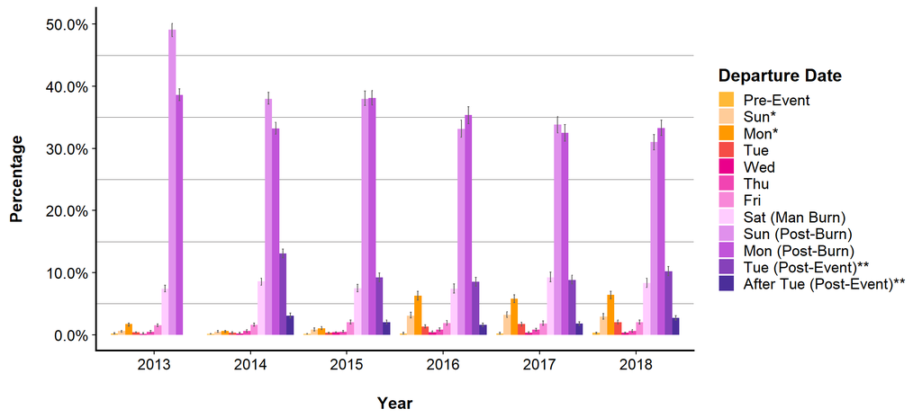

Error bars indicate the upper and lower bounds of the 95% confidence intervals.

* In 2013 and 2014 Burning Man's official opening date fell on a Monday, so for these years Sunday departures should be considered pre-event. From 2015-18 Burning Man opened on a Sunday, so for these years Sunday arrivals should not be considered pre-event departures.  
** Post-event departure data from the 2013 online survey have been removed because the survey question in 2013 was less precise than it was in later years, so the 2013 pre-event data is not directly comparable.

|  | 2013 Percent | 2013 MoE +/- % |  | 2014 Percent | 2014 MoE +/- % |  | 2015 Percent | 2015 MoE +/- % |  | 2016 Percent | 2016 MoE +/- % |  | 2017 Percent | 2017 MoE +/- % |  | 2018 Percent | 2018 MoE +/- % |
| --- | --- | --- | --- | --- | --- | --- | --- | --- | --- | --- | --- | --- | --- | --- | --- | --- | --- |
| Pre-Event | 0.2 | 0.0 |  | 0.1 | 0.0 |  | 0.1 | 0.0 |  | 0.2 | 0.2 |  | 0.2 | 0.2 |  | 0.3 | 0.2 |
| Sun* | 0.6 | 0.2 |  | 0.5 | 0.2 |  | 0.8 | 0.2 |  | 3.1 | 0.4 |  | 3.2 | 0.4 |  | 2.9 | 0.4 |
| Mon* | 1.7 | 0.2 |  | 0.6 | 0.2 |  | 1.0 | 0.2 |  | 6.3 | 0.6 |  | 5.8 | 0.6 |  | 6.4 | 0.6 |
| Tue | 0.4 | 0.2 |  | 0.3 | 0.2 |  | 0.3 | 0.2 |  | 1.3 | 0.2 |  | 1.7 | 0.4 |  | 2.0 | 0.4 |
| Wed | 0.1 | 0.0 |  | 0.2 | 0.2 |  | 0.4 | 0.2 |  | 0.4 | 0.2 |  | 0.3 | 0.2 |  | 0.3 | 0.2 |
| Thu | 0.5 | 0.2 |  | 0.6 | 0.2 |  | 0.5 | 0.2 |  | 0.8 | 0.2 |  | 0.8 | 0.2 |  | 0.6 | 0.2 |
| Fri | 1.5 | 0.2 |  | 1.6 | 0.2 |  | 2.0 | 0.4 |  | 1.9 | 0.4 |  | 1.8 | 0.4 |  | 2.0 | 0.4 |
| Sat (Man Burn) | 7.4 | 0.6 |  | 8.6 | 0.6 |  | 7.5 | 0.6 |  | 7.4 | 0.8 |  | 9.2 | 0.8 |  | 8.3 | 0.8 |
| Sun (Post-Burn) | 49.1 | 1.0 |  | 38.0 | 1.0 |  | 38.0 | 1.2 |  | 33.1 | 1.4 |  | 33.8 | 1.4 |  | 31.0 | 1.2 |
| Mon (Post-Burn) | 38.6 | 1.0 |  | 33.2 | 1.0 |  | 38.1 | 1.2 |  | 35.4 | 1.4 |  | 32.5 | 1.4 |  | 33.3 | 1.2 |
| Tue (Post-Event)** | NA | NA |  | 13.1 | 0.8 |  | 9.2 | 0.6 |  | 8.5 | 0.8 |  | 8.8 | 0.8 |  | 10.2 | 0.8 |
| After Tue (Post-Event)** | NA | NA |  | 3.1 | 0.4 |  | 2.0 | 0.4 |  | 1.6 | 0.2 |  | 1.8 | 0.4 |  | 2.7 | 0.4 |

## Length of Stay*

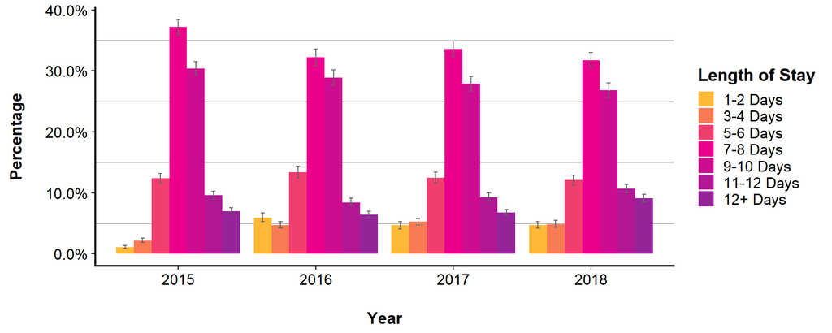

Error bars indicate the upper and lower bounds of the 95% confidence intervals.

* While the Burning Man event lasts only 8 days, some staff, volunteers, and artists arrive before Gate opens to build the city and the art, and some stay after for the playa restoration process.

|  | 2015 Percent | 2015 MoE +/- % |  | 2016 Percent | 2016 MoE +/- % |  | 2017 Percent | 2017 MoE +/- % |  | 2018 Percent | 2018 MoE +/- % |
| --- | --- | --- | --- | --- | --- | --- | --- | --- | --- | --- | --- |
| 1-2 Days | 1.1 | 0.2 |  | 5.9 | 0.8 |  | 4.7 | 0.6 |  | 4.7 | 0.6 |
| 3-4 Days | 2.2 | 0.4 |  | 4.7 | 0.6 |  | 5.3 | 0.6 |  | 4.9 | 0.6 |
| 5-6 Days | 12.4 | 0.8 |  | 13.4 | 1.0 |  | 12.5 | 1.0 |  | 12.1 | 0.8 |
| 7-8 Days | 37.2 | 1.2 |  | 32.2 | 1.4 |  | 33.6 | 1.4 |  | 31.7 | 1.2 |
| 9-10 Days | 30.4 | 1.2 |  | 28.9 | 1.4 |  | 27.9 | 1.2 |  | 26.8 | 1.2 |
| 11-12 Days | 9.6 | 0.6 |  | 8.4 | 0.6 |  | 9.3 | 0.6 |  | 10.7 | 0.6 |
| 12+ Days | 7.0 | 0.6 |  | 6.4 | 0.6 |  | 6.8 | 0.6 |  | 9.1 | 0.6 |

## Ports of Travel

### Common Airports Visited en Route to BRC

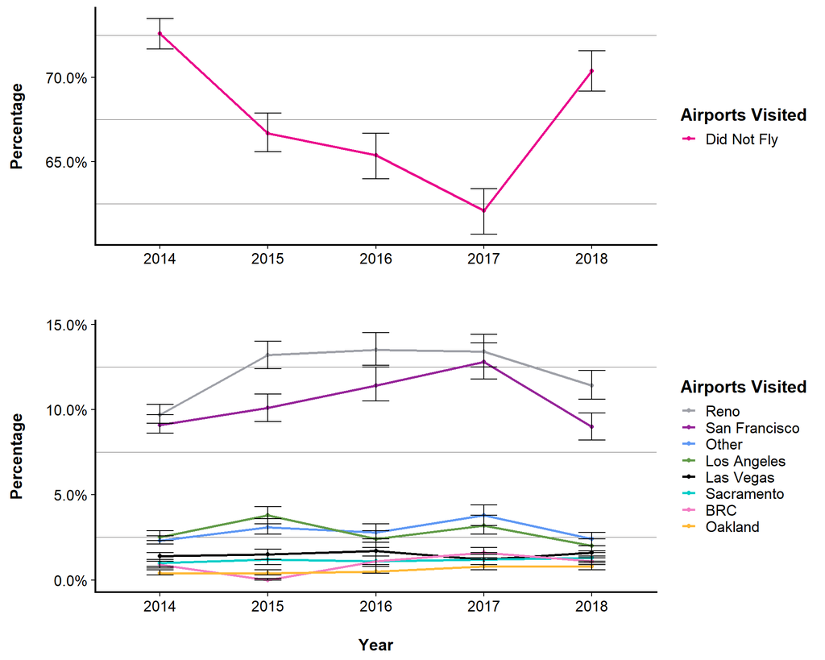

Error bars indicate the upper and lower bounds of the 95% confidence intervals.

|  | 2014 Percent | 2014 MoE +/- % |  | 2015 Percent | 2015 MoE +/- % |  | 2016 Percent | 2016 MoE +/- % |  | 2017 Percent | 2017 MoE +/- % |  | 2018 Percent | 2018 MoE +/- % |
| --- | --- | --- | --- | --- | --- | --- | --- | --- | --- | --- | --- | --- | --- | --- |
| Did Not Fly | 72.6 | 0.8 |  | 66.7 | 1.2 |  | 65.4 | 1.4 |  | 62.1 | 1.4 |  | 70.4 | 1.2 |
| Reno | 9.7 | 0.6 |  | 13.2 | 0.8 |  | 13.5 | 1.0 |  | 13.4 | 1.0 |  | 11.4 | 0.8 |
| San Francisco | 9.1 | 0.6 |  | 10.1 | 0.8 |  | 11.4 | 1.0 |  | 12.8 | 1.0 |  | 9.0 | 0.8 |
| Other | 2.3 | 0.2 |  | 3.1 | 0.4 |  | 2.8 | 0.4 |  | 3.8 | 0.6 |  | 2.4 | 0.4 |
| Los Angeles | 2.5 | 0.4 |  | 3.8 | 0.6 |  | 2.4 | 0.6 |  | 3.2 | 0.6 |  | 2.0 | 0.4 |
| Las Vegas | 1.4 | 0.2 |  | 1.5 | 0.4 |  | 1.7 | 0.4 |  | 1.2 | 0.4 |  | 1.6 | 0.4 |
| Sacramento | 1.0 | 0.2 |  | 1.2 | 0.2 |  | 1.1 | 0.2 |  | 1.2 | 0.4 |  | 1.3 | 0.4 |
| BRC | 0.9 | 0.2 |  | 0.0 | 0.0 |  | 1.1 | 0.4 |  | 1.6 | 0.4 |  | 1.1 | 0.2 |
| Oakland | 0.4 | 0.2 |  | 0.4 | 0.2 |  | 0.5 | 0.2 |  | 0.8 | 0.2 |  | 0.8 | 0.2 |

## Ports of Travel

### Port of Entry into BRC

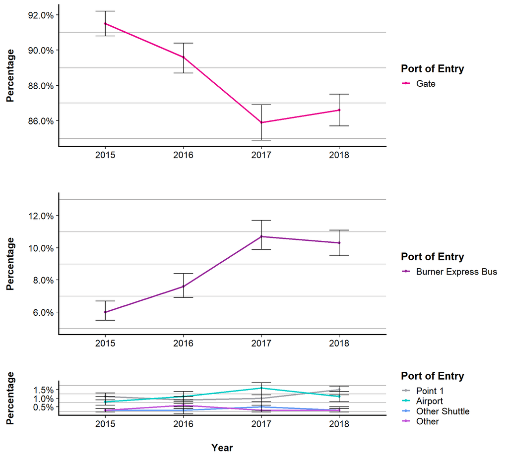

Error bars indicate the upper and lower bounds of the 95% confidence intervals.

|  | 2015 Percent | 2015 MoE +/- % |  | 2016 Percent | 2016 MoE +/- % |  | 2017 Percent | 2017 MoE +/- % |  | 2018 Percent | 2018 MoE +/- % |
| --- | --- | --- | --- | --- | --- | --- | --- | --- | --- | --- | --- |
| Gate | 91.5 | 0.8 |  | 89.6 | 0.8 |  | 85.9 | 1.0 |  | 86.6 | 1.0 |
| Burner Express Bus | 6.0 | 0.6 |  | 7.6 | 0.8 |  | 10.7 | 1.0 |  | 10.3 | 0.8 |
| Point 1 | 1.1 | 0.2 |  | 0.9 | 0.2 |  | 1.0 | 0.2 |  | 1.5 | 0.2 |
| Airport | 0.8 | 0.2 |  | 1.1 | 0.4 |  | 1.6 | 0.4 |  | 1.1 | 0.2 |
| Other Shuttle | 0.3 | 0.2 |  | 0.3 | 0.2 |  | 0.5 | 0.2 |  | 0.3 | 0.2 |
| Other | 0.3 | 0.2 |  | 0.6 | 0.2 |  | 0.3 | 0.2 |  | 0.3 | 0.2 |

## Ports of Travel

### Port of Departure from BRC*

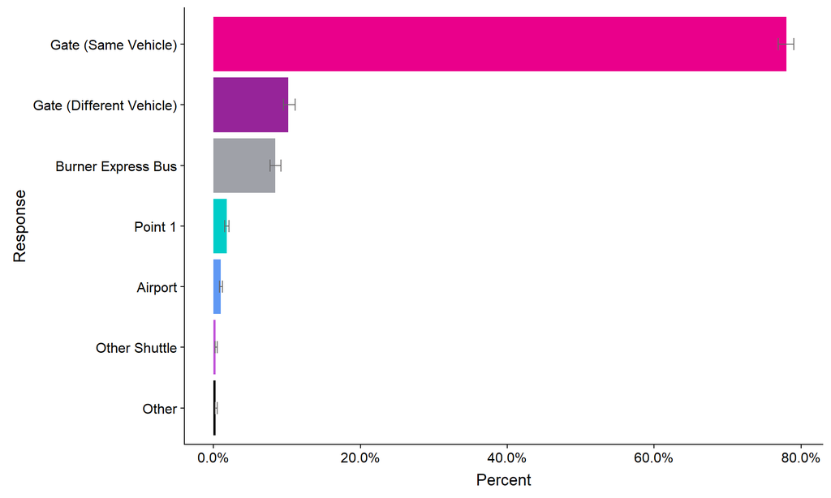

Error bars indicate the upper and lower bounds of the 95% confidence intervals.

* This question was first introduced in the 2018 online survey.

|  | 2018 Percent | 2018 MoE +/- % |
| --- | --- | --- |
| Gate (Same Vehicle) | 78.0 | 1.0 |
| Gate (Different Vehicle) | 10.2 | 0.8 |
| Burner Express Bus | 8.4 | 0.8 |
| Point 1 | 1.8 | 0.4 |
| Airport | 1.0 | 0.2 |
| Other Shuttle | 0.3 | 0.2 |
| Other | 0.3 | 0.2 |

**Next:** Transportation: Vehicle Type, Trailer Towing, and Vehicle Occupancy